# Alien radio signal

## Background

Imagine we have obtained a USB thumb drive from a top secret project from Area 51 in Nevada.

After hours of decryption and cracking passwords we ended up with a data table with sensor data.

It is not clear what kind of sensor we are talking about.

Your job will be to analyze the file and look for hidden messages in the file.

```r
library(tidyverse)
options(digits = 7) # number of digits printed by R default (vectors, data.frames, lists)
options(pillar.sigfig = 7) # number of digits printed by tibbles default.

df <- read_rds("Assignment\\Assignment 2\\t2.alien_radio_signal.rds")
```

> Q2.1 How many columns do we have in the data?

```r
ncol(df)
```

```
## [1] 4
```

Look at the “group” variable.

> Q2.2 How many groups do we have in the data?

```r
n_distinct(df$group)
```

```
## [1] 3
```

> Q2.3 What is the mean signal strength?

```r
mean(df$signal_strength, na.rm = TRUE)
```

```
## [1] 10.00527
```

> Q2.4 Which of the following statements is true?

Hint: plot the distribution of values for each group

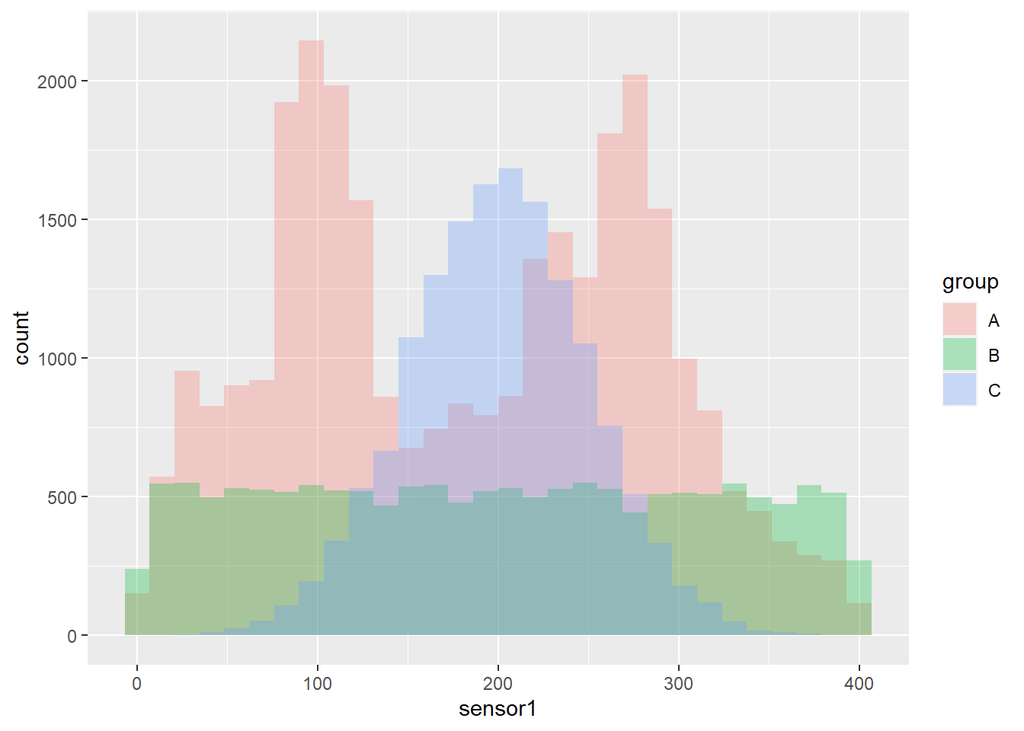

```r
df %>%
    ggplot(aes(x = sensor1, fill = group)) +
    geom_histogram(position = "identity", alpha = 0.3, )
```

1. Sensor 1 show a normal distribution of values in Group A and a uniform (flat) distribution of values in Group B
2. Sensor 1 show a normal distribution of values in Group A and a uniform (flat) distribution of values in Group C
3. Sensor 1 show a normal distribution of values in Group B and a uniform (flat) distribution of values in Group A
4. Sensor 1 show a normal distribution of values in Group B and a uniform (flat) distribution of values in Group C
5. Sensor 1 show a normal distribution of values in Group C and a uniform (flat) distribution of values in Group A
6. Sensor 1 show a normal distribution of values in Group C and a uniform (flat) distribution of values in Group B

The answer should be given as a single number: 1, 2, 3..

6

> Q2.5 What is the mean sensor 2 value in group A?

```r
df %>%
    filter(group == "A") %>%
    select(sensor2) %>%
    colMeans()
```

```
##  sensor2
## 159.7881
```